# L4 Event Study with Factor Model

FIN 3080

Week 9-10

## Header

```r
setwd("C:/Users/siche/Documents/teaching/Introduction to Financial Data Analysis/L4")
library(RPostgres)
library(tidyr)
library(dplyr)
```

## Step 1. Connect to WRDS and get Netflix daily returns from July 23, 2012 to July 22, 2013

#### Netflix stock ticker is NFLX

```r
q="select distinct permno,ticker from CRSP.DSENAMES where ticker = 'NFLX'"
res = dbSendQuery(wrds, q)
ticker = dbFetch(res, n=-1)
dbClearResult(res)
```

```r
q = paste0("select date,ret as nflx, prc as nflx_prc from CRSP.DSF where permno = '",
         ticker$permno,
         "' and date>='2012-07-23' and date<='2013-07-23'")
res = dbSendQuery(wrds, q)
nflx = dbFetch(res, n=-1)
dbClearResult(res)
```

```r
head(nflx)
```

```
##         date         nflx nflx_prc
## 1 2012-07-23 -0.022977233    79.94
## 2 2012-07-24  0.005629184    80.39
## 3 2012-07-25 -0.250155509    60.28
## 4 2012-07-26 -0.054246858    57.01
## 5 2012-07-27  0.033502892    58.92
## 6 2012-07-30 -0.019857403    57.75
```

## Step 2. Get SP500 Index returns from COMPUSTAT

#### Get all the indices id, in COMPUSTAT, it is gvkeyx

```r
q = paste0("select conm,gvkeyx from COMP.IDX_INDEX")
res = dbSendQuery(wrds,q)
indices = dbFetch(res,n = -1)
```

```r
head(indices)
```

```
##                           conm gvkeyx
## 1          S&P Industrials-Wed 000001
## 2          S&P Industrials-Ltd 000002
## 3             S&P 500 Comp-Ltd 000003
## 4  American Stock Exchange Ind 000004
## 5 Dow Jones Industrials-30 Stk 000005
## 6  Dow Jones Transportation-20 000006
```

#### SP500’s gvykey is 000003, get it’s daily return from idx_daily

```r
q = "select datadate as date,prccddiv as sp500 from COMP.IDX_DAILY where gvkeyx = '000003' and datadate<='2013-07-23' and datadate>='2012-07-20'"
res = dbSendQuery(wrds,q)
sp500 = dbFetch(res,n = -1)
```

```r
head(sp500)
sp500 = sp500 %>% arrange(date) %>%
  mutate(sp500 = sp500/lag(sp500,1)-1) %>%
  na.omit()
```

```r
head(sp500)
```

```
##         date         sp500
## 2 2012-07-23 -0.0088889884
## 3 2012-07-24 -0.0090357945
## 4 2012-07-25 -0.0002956357
## 5 2012-07-26  0.0165699159
## 6 2012-07-27  0.0191384148
## 7 2012-07-30 -0.0004482409
```

## Step 3. Get Risk-free return from Fama French website

```r
ff = read.csv("ff_daily.csv",skip = 4)
head(ff)
```

```
##          X Mkt.RF   SMB   HML    RF
## 1 19260701   0.10 -0.24 -0.28 0.009
## 2 19260702   0.45 -0.32 -0.08 0.009
## 3 19260706   0.17  0.27 -0.35 0.009
## 4 19260707   0.09 -0.59  0.03 0.009
## 5 19260708   0.21 -0.36  0.15 0.009
## 6 19260709  -0.71  0.44  0.56 0.009
```

```r
colnames(ff) = c("date","mkt.rf","smb","hml","rf")
ff$date = as.Date(ff$date,"%Y%m%d")

head(ff)
```

```
##         date mkt.rf   smb   hml    rf
## 1 1926-07-01   0.10 -0.24 -0.28 0.009
## 2 1926-07-02   0.45 -0.32 -0.08 0.009
## 3 1926-07-06   0.17  0.27 -0.35 0.009
## 4 1926-07-07   0.09 -0.59  0.03 0.009
## 5 1926-07-08   0.21 -0.36  0.15 0.009
## 6 1926-07-09  -0.71  0.44  0.56 0.009
```

```r
ff = ff %>% mutate_at(vars(mkt.rf,smb,hml,rf),function(x) x/100)

save(ff,file='ff_daily.RData')

ff = ff %>% select(date,rf) %>%
  filter((date>='2012-07-23')&(date<='2013-07-23'))
head(ff)
```

```
##         date rf
## 1 2012-07-23  0
## 2 2012-07-24  0
## 3 2012-07-25  0
## 4 2012-07-26  0
## 5 2012-07-27  0
## 6 2012-07-30  0
```

## Step 4. Merge the nflx, sp500 and ff by date

#### Check whether all the dates are in the same data type before merge

```r
class(nflx$date)
```

```
## [1] "Date"
```

```r
class(sp500$date)
```

```
## [1] "Date"
```

```r
class(ff$date)
```

```
## [1] "Date"
```

```r
nflx.mkt = nflx %>%
  left_join(sp500,by='date') %>%
  left_join(ff,by='date')
```

## Step 5. Excess returns of nflx and sp500

#### mutate_at(vars(),function(x) x+1)

#### mutate_at(vars(),~.+1, use ~ to represent function(x) and use . to represent x

#### mutate_at(vars(),list(function(x) x+1, function(x) x+2))

#### mutate_at(vars(),list(~.+1, ~.+2))

```r
mydf = data.frame(matrix(seq(1,20),4))
mydf
```

```
##   X1 X2 X3 X4 X5
## 1  1  5  9 13 17
## 2  2  6 10 14 18
## 3  3  7 11 15 19
## 4  4  8 12 16 20
```

```r
mydf2 = mydf %>% mutate_at(vars(X1,X2),function(x) x-1)
mydf2
```

```
##   X1 X2 X3 X4 X5
## 1  0  4  9 13 17
## 2  1  5 10 14 18
## 3  2  6 11 15 19
## 4  3  7 12 16 20
```

```r
mydf3 = mydf %>% mutate_at(vars(X1,X2),~.+1)
mydf3
```

```
##   X1 X2 X3 X4 X5
## 1  2  6  9 13 17
## 2  3  7 10 14 18
## 3  4  8 11 15 19
## 4  5  9 12 16 20
```

```r
nflx.mkt = nflx.mkt %>%
  mutate_at(vars(nflx,sp500),~.-rf) %>%
  select(date,nflx,sp500) %>%
  rename_at(vars(nflx,sp500),~paste0(.,".rf"))

head(nflx.mkt)
```

```
##         date      nflx.rf      sp500.rf
## 1 2012-07-23 -0.022977233 -0.0088889884
## 2 2012-07-24  0.005629184 -0.0090357945
## 3 2012-07-25 -0.250155509 -0.0002956357
## 4 2012-07-26 -0.054246858  0.0165699159
## 5 2012-07-27  0.033502892  0.0191384148
## 6 2012-07-30 -0.019857403 -0.0004482409
```

```r
tail(nflx.mkt)
```

```
##           date      nflx.rf     sp500.rf
## 246 2013-07-16  0.009690673 -0.003709957
## 247 2013-07-17  0.028562661  0.002885750
## 248 2013-07-18 -0.005636047  0.005143359
## 249 2013-07-19 -0.006884182  0.001639261
## 250 2013-07-22 -0.009887508  0.002051849
## 251 2013-07-23 -0.044663299 -0.001852374
```

## Step 6. Perform market model regression during the estimation period

```r
nflx.mkt.est = nflx.mkt %>% filter(date<'2013-07-23')
tail(nflx.mkt.est)
```

```
##           date      nflx.rf     sp500.rf
## 245 2013-07-15  0.002794923  0.001377707
## 246 2013-07-16  0.009690673 -0.003709957
## 247 2013-07-17  0.028562661  0.002885750
## 248 2013-07-18 -0.005636047  0.005143359
## 249 2013-07-19 -0.006884182  0.001639261
## 250 2013-07-22 -0.009887508  0.002051849
```

```r
mkt.model = lm(nflx.rf~sp500.rf,data = nflx.mkt.est)
mkt.model.summary = summary(mkt.model)
mkt.model.summary
```

```
##
## Call:
## lm(formula = nflx.rf ~ sp500.rf, data = nflx.mkt.est)
##
## Residuals:
##      Min       1Q   Median       3Q      Max
## -0.25460 -0.01955 -0.00621  0.01389  0.41745
##
## Coefficients:
##             Estimate Std. Error t value Pr(>|t|)
## (Intercept) 0.004748   0.003060   1.552   0.1220
## sp500.rf    1.019505   0.401526   2.539   0.0117 *
## ---
## Signif. codes:  0 '***' 0.001 '**' 0.01 '*' 0.05 '.' 0.1 ' ' 1
##
## Residual standard error: 0.04797 on 248 degrees of freedom
## Multiple R-squared:  0.02534,    Adjusted R-squared:  0.02141
## F-statistic: 6.447 on 1 and 248 DF,  p-value: 0.01173
```

## Step 7. Calculate Abnormal Return, t-Statistic, and p-Value for Dates in Event Window

#### Select the event window

```r
nflx.mkt.event = nflx.mkt %>% filter(date=='2013-07-23')
nflx.mkt.event
```

```
##         date    nflx.rf     sp500.rf
## 1 2013-07-23 -0.0446633 -0.001852374
```

#### Calculate the predicted return.

```r
nflx.mkt.event$pret = mkt.model$coefficients[1] + mkt.model$coefficients[2]*nflx.mkt.event$sp500.rf
```

#### Calculate the abnormal return on 07-23

```r
nflx.mkt.event$ab.ret = nflx.mkt.event$nflx.rf-nflx.mkt.event$pret
```

#### The residual’s standard deviation

```r
r.sigma = mkt.model.summary$sigma
```

#### The redidual return after adjusted by standard deviation should follow student t distribution.

```r
nflx.mkt.event$tstat = nflx.mkt.event$ab.ret/r.sigma
nflx.mkt.event
```

```
##         date    nflx.rf     sp500.rf        pret    ab.ret      tstat
## 1 2013-07-23 -0.0446633 -0.001852374 0.002859705 -0.047523 -0.9907373
```

#### Calculate p value

- pt(tstat) gives the distribution function of student t distribution
- 2(1-pt(abs(tStat),df)) gives the two-sided t-test p-value

```r
nflx.mkt.event$pval = 2*(1-pt(abs(nflx.mkt.event$tstat),
                              df=nrow(nflx.mkt.est)-2))

nflx.mkt.event
```

```
##         date    nflx.rf     sp500.rf        pret    ab.ret      tstat
## 1 2013-07-23 -0.0446633 -0.001852374 0.002859705 -0.047523 -0.9907373
##        pval
## 1 0.3227795
```

- The pval is 0.32 and is not statistically significant at conventional levels of significance, indicating even though the return on July 23 is large, it is not abnormal

## Step 8. Check the performance of Netflix ahead of the event

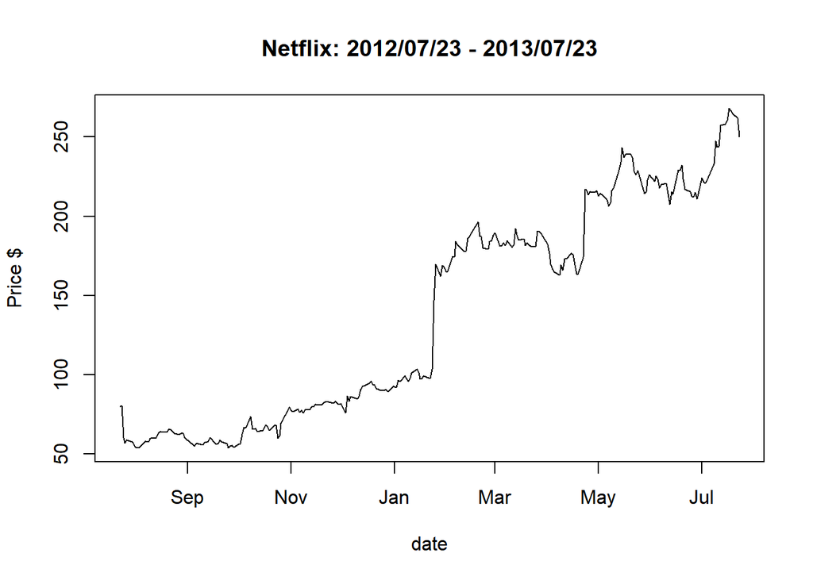

```r
plot(nflx$nflx_prc~nflx$date,
     type='l', xlab = 'date', ylab = 'Price $',
     main='Netflix: 2012/07/23 - 2013/07/23')
```

- There are a couple of huge price jumps, making the volatility very large.

## Step 9. Choose another estimation period after the price jump by removing some outlier returns

#### Price chart shows that Netflix stock had a couple of large price jumps in Jan and in April

#### These returns are not “normal” returns

#### Estimate the market model without the outlier returns

- Order the returns find the largest couple of returns in absolute value and their dates

```r
ret.order = nflx[order(-abs(nflx$nflx)),]
head(ret.order)
```

```
##           date       nflx nflx_prc
## 127 2013-01-24  0.4222351 146.8600
## 3   2012-07-25 -0.2501555  60.2800
## 188 2013-04-23  0.2444228 216.9900
## 128 2013-01-25  0.1545690 169.5600
## 93  2012-12-04  0.1401197  86.6491
## 70  2012-10-31  0.1388244  79.2394
```

- Remove outliers at 1% quantile in absolute value. That is about 3 days.

```r
nflx.mkt.est2 = subset(nflx.mkt,
                       (date<'2013-07-23') & (abs(nflx.rf)<quantile(abs(nflx.rf),0.99,type=3)))

summary(nflx.mkt.est2)
```

```
##       date               nflx.rf              sp500.rf
##  Min.   :2012-07-23   Min.   :-0.1187673   Min.   :-0.0248566
##  1st Qu.:2012-10-18   1st Qu.:-0.0137290   1st Qu.:-0.0030457
##  Median :2013-01-20   Median : 0.0002569   Median : 0.0009378
##  Mean   :2013-01-20   Mean   : 0.0035319   Mean   : 0.0009448
##  3rd Qu.:2013-04-23   3rd Qu.: 0.0179727   3rd Qu.: 0.0052604
##  Max.   :2013-07-22   Max.   : 0.1401098   Max.   : 0.0255983
```

```r
mkt.model2 = lm(nflx.rf~sp500.rf, nflx.mkt.est2)
mkt.model2.summary = summary(mkt.model2)
```

## Step 10. Calculate the Market Model Parameters of this Alternative Estimation Period

```r
nflx.mkt.event = nflx.mkt %>% filter(date=='2013-07-23')

nflx.mkt.event$pret = mkt.model2$coefficients[1] +
  mkt.model2$coefficients[2]*nflx.mkt.event$sp500.rf

nflx.mkt.event$ab.ret = nflx.mkt.event$nflx.rf-nflx.mkt.event$pret

r.sigma2 = mkt.model2.summary$sigma

nflx.mkt.event$tstat = nflx.mkt.event$ab.ret/r.sigma2

nflx.mkt.event$pval = 2*(1-pt(abs(nflx.mkt.event$tstat),
                              df=nrow(nflx.mkt.est2)-2))

nflx.mkt.event
```

```
##         date    nflx.rf     sp500.rf        pret      ab.ret     tstat
## 1 2013-07-23 -0.0446633 -0.001852374 0.001224683 -0.04588798 -1.415183
##        pval
## 1 0.1582898
```

- Without the outliers, the return is still not significant, indicating the return is within the tolerance.